# R Refresher

Rob Williams

August 23, 2017

All examples in this document use default R datasets.

- Create a 10 length vector that goes from 0 to 9, but replace the 5 with 15

```r
x <- 0:9
x[6] <- 15
x <- c(0:4, 15, 6:9) # do it in one line
x
```

```
##  [1]  0  1  2  3  4 15  6  7  8  9
```

- Multiply a vector by a scalar

```r
45:57 * .42
```

```
##  [1] 18.90 19.32 19.74 20.16 20.58 21.00 21.42 21.84 22.26 22.68 23.10
## [12] 23.52 23.94
```

- Matrix multiply a vector by a $10 \times 4$ matrix of draws from a Beta(2,1) distribution

```r
1:10 %*% matrix(rbeta(400, 2, 1), nrow = 10, ncol = 4)
```

```
##       [,1]  [,2]  [,3] [,4]
## [1,] 33.02 34.13 39.78 34.4
```

- Subset the `Seatbelts` data to include only the `drivers`, `rear`, `PetrolPrice`, and `law` columns

```r
data.frame(Seatbelts[, c('drivers', 'rear', 'PetrolPrice', 'law')])
```

| drivers | rear | PetrolPrice | law |
| --- | --- | --- | --- |
| 1687 | 269 | 0.10297 | 0 |
| 1508 | 265 | 0.10236 | 0 |
| 1507 | 319 | 0.10206 | 0 |
| 1385 | 407 | 0.10087 | 0 |
| 1632 | 454 | 0.10102 | 0 |
| 1511 | 427 | 0.10058 | 0 |
| 1559 | 522 | 0.10377 | 0 |
| 1630 | 536 | 0.10408 | 0 |
| 1579 | 405 | 0.10377 | 0 |
| 1653 | 437 | 0.10303 | 0 |

[output cut: 182 more lines]

- Subset the `CO2` data to include only observations where the plant’s CO$_2$ uptake rate is less than or equal to 15

```r
CO2[which(CO2$uptake <= 15), ]
```

| Plant | Type | Treatment | conc | uptake |
| --- | --- | --- | --- | --- |
| Qn2 | Quebec | nonchilled | 95 | 13.6 |
| Qc1 | Quebec | chilled | 95 | 14.2 |
| Qc2 | Quebec | chilled | 95 | 9.3 |
| Mn1 | Mississippi | nonchilled | 95 | 10.6 |
| Mn2 | Mississippi | nonchilled | 95 | 12.0 |
| Mn3 | Mississippi | nonchilled | 95 | 11.3 |
| Mc1 | Mississippi | chilled | 95 | 10.5 |
| Mc1 | Mississippi | chilled | 175 | 14.9 |
| Mc2 | Mississippi | chilled | 95 | 7.7 |
| Mc2 | Mississippi | chilled | 175 | 11.4 |

[output cut: 6 more lines]

- Sort the `mtcars` data in ascending order by cylinders and miles per gallon

```r
mtcars[order(mtcars$cyl, mtcars$mpg), ]
```

| mpg | cyl | disp | hp | drat | wt | qsec | vs | am | gear | carb |
| --- | --- | --- | --- | --- | --- | --- | --- | --- | --- | --- |
| 21.4 | 4 | 121.0 | 109 | 4.11 | 2.780 | 18.60 | 1 | 1 | 4 | 2 |
| 21.5 | 4 | 120.1 | 97 | 3.70 | 2.465 | 20.01 | 1 | 0 | 3 | 1 |
| 22.8 | 4 | 108.0 | 93 | 3.85 | 2.320 | 18.61 | 1 | 1 | 4 | 1 |
| 22.8 | 4 | 140.8 | 95 | 3.92 | 3.150 | 22.90 | 1 | 0 | 4 | 2 |
| 24.4 | 4 | 146.7 | 62 | 3.69 | 3.190 | 20.00 | 1 | 0 | 4 | 2 |
| 26.0 | 4 | 120.3 | 91 | 4.43 | 2.140 | 16.70 | 0 | 1 | 5 | 2 |
| 27.3 | 4 | 79.0 | 66 | 4.08 | 1.935 | 18.90 | 1 | 1 | 4 | 1 |
| 30.4 | 4 | 75.7 | 52 | 4.93 | 1.615 | 18.52 | 1 | 1 | 4 | 2 |
| 30.4 | 4 | 95.1 | 113 | 3.77 | 1.513 | 16.90 | 1 | 1 | 5 | 2 |
| 32.4 | 4 | 78.7 | 66 | 4.08 | 2.200 | 19.47 | 1 | 1 | 4 | 1 |

[output cut: 22 more lines]

- Generate 10000 draws from a $\mathcal{N}(2, .89)$ distribution, and plot their density

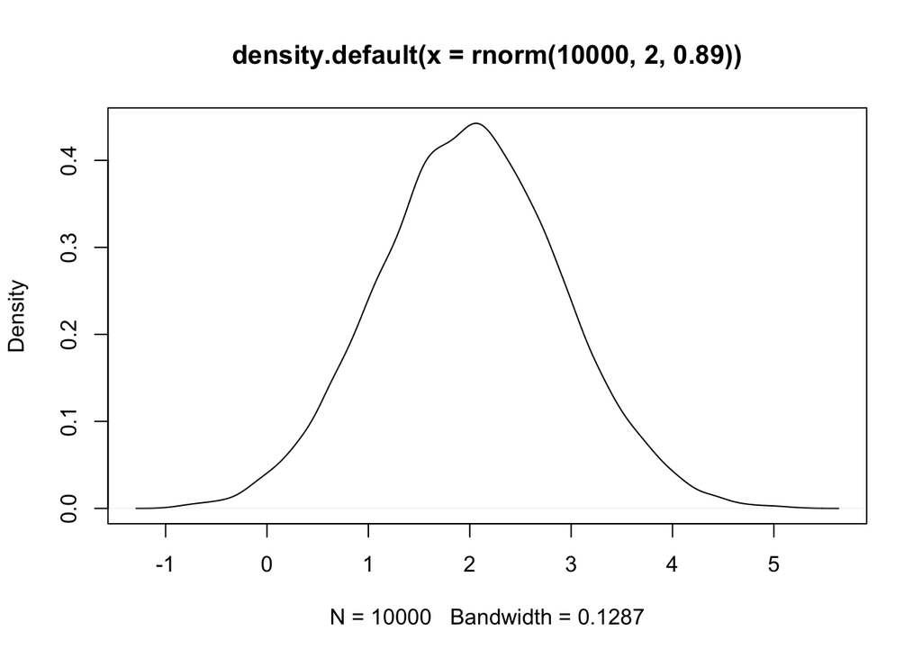

```r
plot(density(rnorm(1e4, 2, .89)))
```

- Call the `invlogit()` function from `arm` *without* loading the package

```r
arm::invlogit(.034)
```

```
## [1] 0.5085
```

- Using the `mtcars` data, fit a linear model that explains variation in miles per gallon as a function of number of cylinders, displacement, and horsepower. Extract the coefficients, standard error, and R$^2$ from the model.

```r
m1 <- lm(mpg ~ cyl + disp + hp, data = mtcars)
coef(m1)
```

```
## (Intercept)         cyl        disp          hp
##    34.18492    -1.22742    -0.01884    -0.01468
```

```r
sqrt(diag(vcov(m1)))
```

```
## (Intercept)         cyl        disp          hp
##     2.59078     0.79728     0.01040     0.01465
```

```r
summary(m1)$r.squared
```

```
## [1] 0.7679
```

- Use the `Titanic` data to fit a model that explains whether a passenger survived the ship’s sinking as a function of their sex, age, and passenger class, but use a probit link function. What is the difference in coefficient estimates between this model and one using the canonical logit link function?

```r
coef(glm(Survived ~ Class + Sex + Age, data = Titanic, family = binomial(link = 'probit'))) -
  coef(glm(Survived ~ Class + Sex + Age, data = Titanic, family = binomial(link = 'logit')))
```

```
## (Intercept)    Class2nd    Class3rd   ClassCrew   SexFemale    AgeAdult
##  -2.902e-16   3.942e-16   4.920e-16   6.943e-16  -2.156e-16   2.214e-16
```

- Write a loop that generates 1000 draws from a $\mathcal{N}(-2.5, 4)$ distribution, and then records their mean. Run the loop for 10000 iterations and report the mean of the means.

```r
x <- numeric()
for (i in 1:1e4) {

  x[i] <- mean(rnorm(1e3, -2.5, 4))

}
mean(x)
```

```
## [1] -2.501
```

- Write a mean function

```r
my.mean <- function(x) {

  sum(x) / length(x)

}

my.mean(1:7)
```

```
## [1] 4
```

- Write a mean function that can handle NA values

```r
my.mean.NA <- function(x) {

  x <- na.omit(x)
  sum(x) / length(x)

}

my.mean.NA(c(NA, 1:7, NA))
```

```
## [1] 4
```

- Write a function that accepts a vector, squares even integers, and square roots all other numbers

```r
myfunc <- function(x) {

  for (i in 1:length(x)) {

    if (x[i] %% 2 == 0) {

      x[i] <- x[i]^2

    } else {

      x[i] <- sqrt(x[i])

    }

  }

  x

}

myfunc(seq(1, 6, by = .5))
```

```
##  [1]  1.000  1.225  4.000  1.581  1.732  1.871 16.000  2.121  2.236  2.345
## [11] 36.000
```

- Use the `airquality` data to plot wind speed against temperature. Use separate colors for observations in each month, and include a linear fit line for each month.

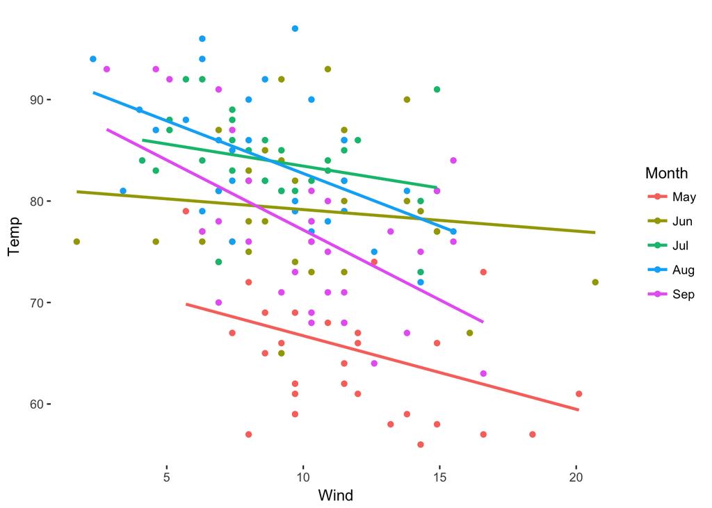

```r
library(ggplot2)
ggplot(data = airquality, aes(x = Wind, y = Temp, color = as.factor(Month))) +
  geom_point() +
  geom_smooth(method = 'lm', se = F) +
  labs(color = 'Month') +
  scale_color_discrete(labels = c('May', 'Jun', 'Jul', 'Aug', 'Sep')) +
  theme_bw() +
  theme(legend.position = 'right',
        plot.background = element_blank(),
        panel.grid.minor = element_blank(),
        panel.grid.major = element_blank(),
        panel.border = element_blank())
```